# A5

For this assignment, we use transaction dataset that included all of the information from bank, and the information about the account for each customer.

##1. the first problem that we solved:

1. Whether an account has a credit card or not
2. Whether an account has a loan and distribution of the loan
3. The distribution of average balance for the account

$~$

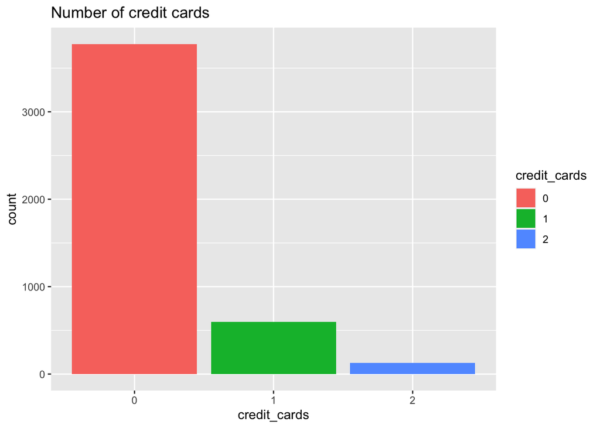

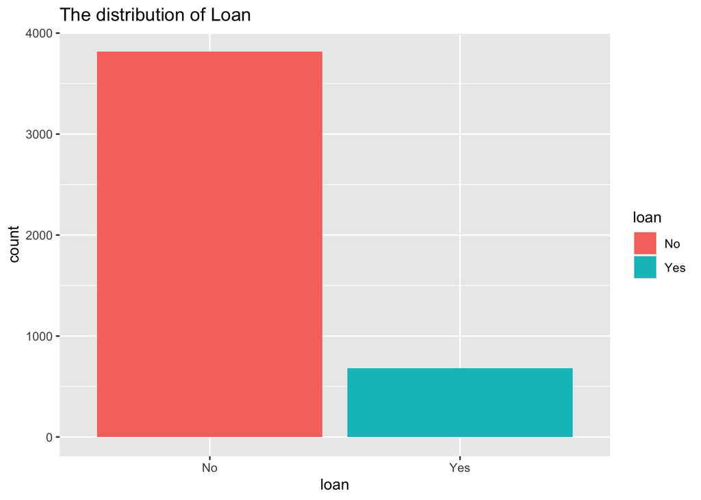

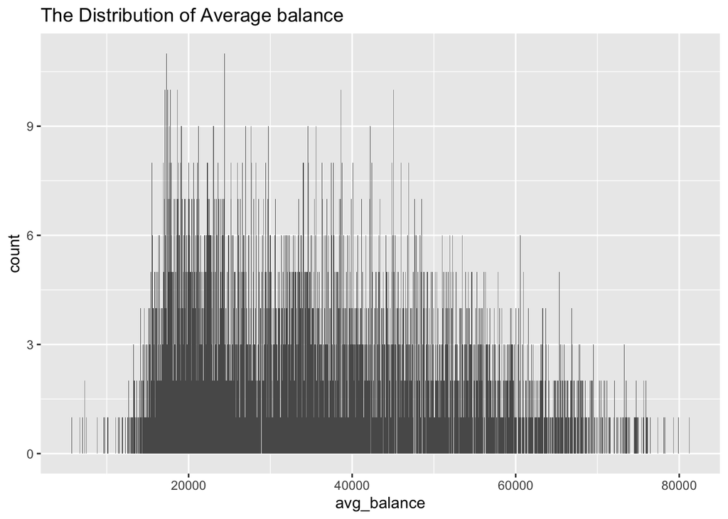

$~$ $~$

from the first graph, we can see that there are more than 3500 accounts do not have credit card. And for second one which is the distribution of loan, most of the accounts don’t have any loan since they do not apply for the credit cards. For third one, the average balance for this account are 20000 and 40000.

$~$ $~$ $~$

##2.The part I figure out the distribution of loan amount, distribution of loan term, distribution of loan status and the distribution of loan default.

$~$

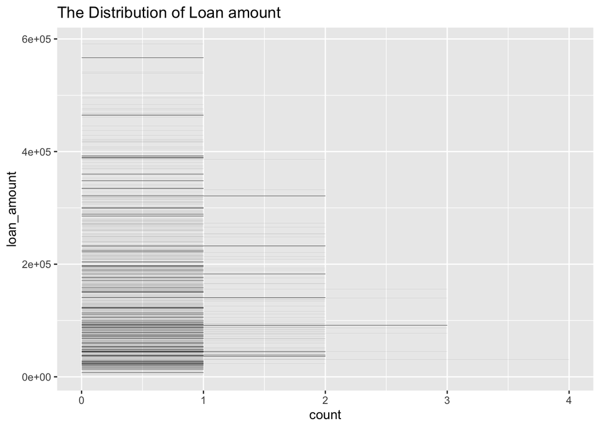

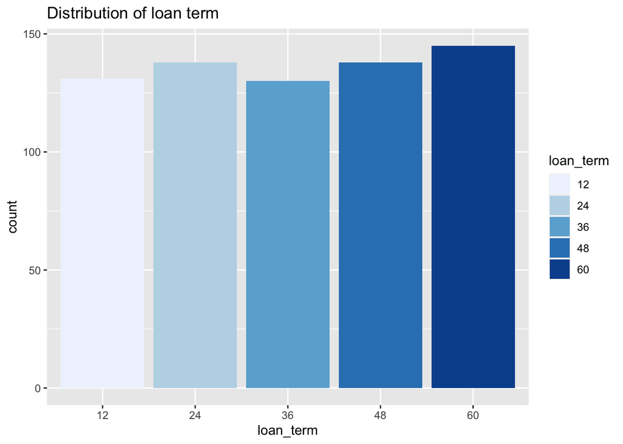

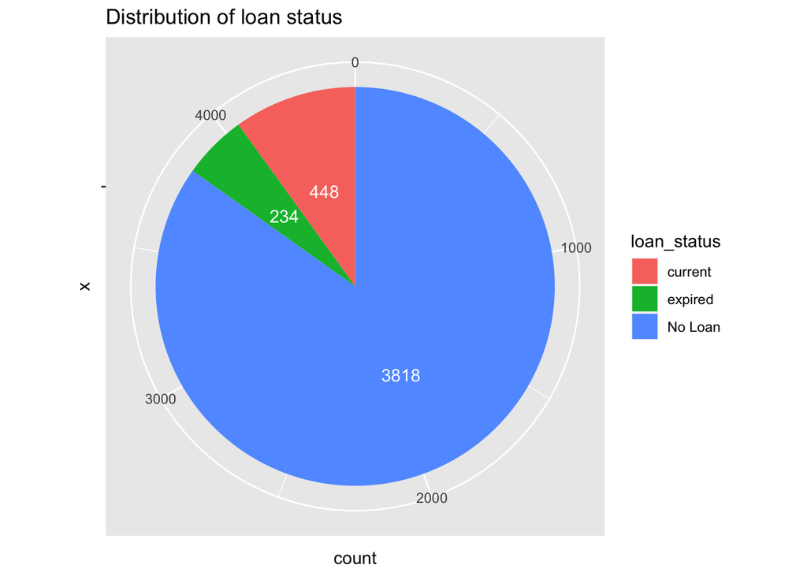

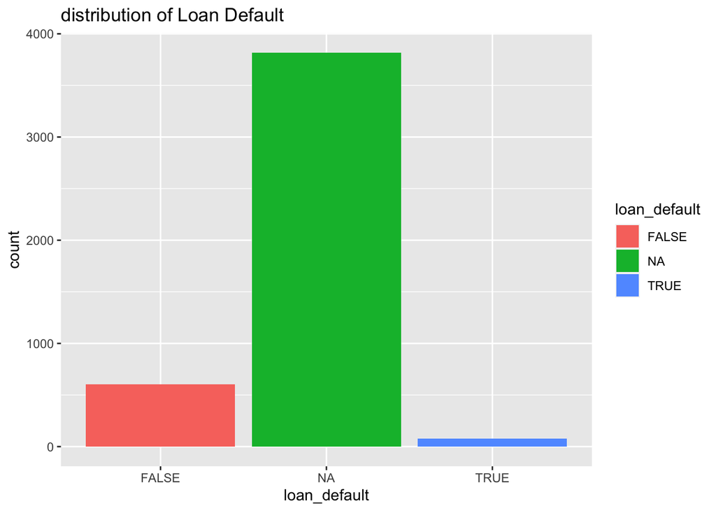

$~$ $~$

$~$ $~$ $~$

$~$ $~$

$~$ $~$ $~$

$~$

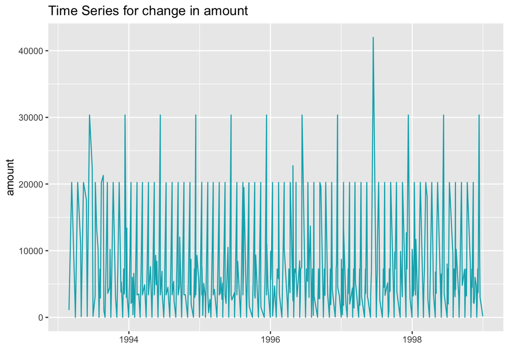

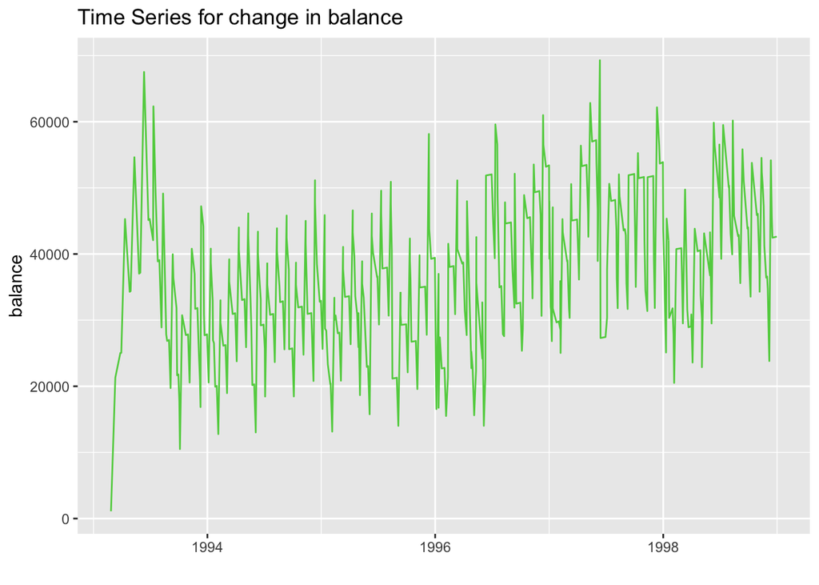

$~$ $~$

for change in amount, the time series plot looks pretty constant except one time between 1997 and 1998. And for changes in balance, it does not pretty constant, and the volatity happened arounf 1994 and 1997.

$~$ $~$ $~$

##5 check whether the account has credits transaction.

$~$

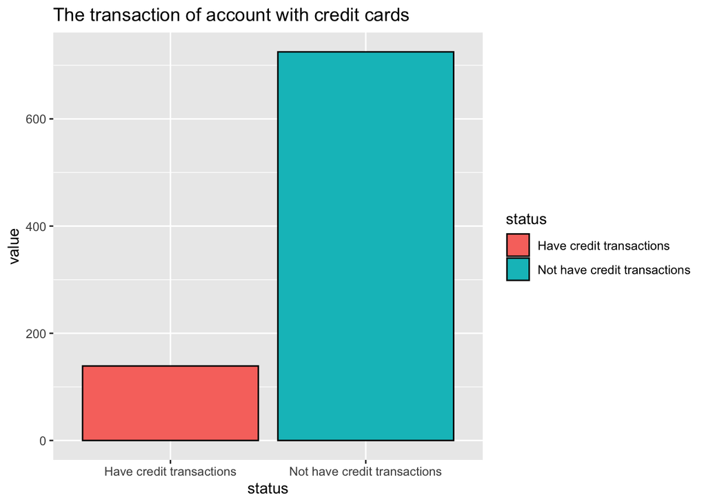

$~$ $~$

the bar plot shows that most of accounts do not have credit transactions.